# TimeSeriesDecompositionAssignment

### Step 1: Importing Data Using Pandas

```python
import pandas as pd
import matplotlib.pyplot as plt
import numpy as np
%matplotlib inline
```

```python
filename = 'C:/Users/ezazz/CTBA/M3/ConstructionTimeSeriesDataV2.csv'
```

```python
dfCon = pd.read_csv(filename)
```

```python
dfCon.head(n=10)
```

|  | Month | Month-Year | Total Construction | Private Construction | Public Construction |
| --- | --- | --- | --- | --- | --- |
| 0 | 1 | Jan-02 | 59516 | 45273 | 14243 |
| 1 | 2 | Feb-02 | 58588 | 44475 | 14113 |
| 2 | 3 | Mar-02 | 63782 | 49396 | 14386 |
| 3 | 4 | Apr-02 | 69504 | 53283 | 16221 |
| 4 | 5 | May-02 | 73384 | 55009 | 18375 |
| 5 | 6 | Jun-02 | 77182 | 57801 | 19381 |
| 6 | 7 | Jul-02 | 78863 | 58494 | 20369 |
| 7 | 8 | Aug-02 | 79460 | 57953 | 21507 |
| 8 | 9 | Sep-02 | 76542 | 55157 | 21385 |
| 9 | 10 | Oct-02 | 75710 | 56023 | 19687 |

Getting an understanding of the data set at a high level

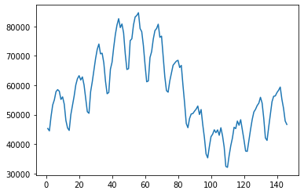

```python
plt.plot(dfCon.Month,dfCon['Private Construction'])
```

Focusing on Private Construction first, looking at the overall relationship between month and construction. There is definitely some cyclicality, but the overall relationship is not linear on first appearance. It almost looks like a sine or cosine funtion

### Part 1, Step 2: Find the moving average of the data to fit a curve to the basic shape, adjusting the window to minimize the average squared error

I took a look at potential window sizes for taking a moving average, looking to find a good balance of minimizing the squared error and having it large enough to find a general curve. I found 28 months had the lowest average squared error per month

```python
dfTest = dfCon
def sqErr(row):
        return(row['Private Construction'] - row['MovAvg'])**2
dfTest['MovAvg'] = np.NaN
dfTest['sqErr'] = np.NaN

for j in range(2,72):
    window = j
    window = window - window % 2
    for i in range(int(window/2), dfTest.shape[0]-int(window/2)):
        dfTest.loc[dfTest.index[i],'MovAvg'] = (0.5*dfTest.iloc[i - int(window/2)]['Private Construction'] + dfTest.iloc[i - int(window/2)+1:i + int(window/2)]['Private Construction'].sum() + 0.5*dfTest.iloc[i + int(window/2)]['Private Construction'])/float(window)

    dfTest['sqErr'] = (dfTest['Private Construction'] - dfTest['MovAvg'])**2

    dfTest.dropna(how='any', inplace=True)

    print('Window = ',j,'Average Squared Error per Month: ',sum(dfTest['sqErr'])/len(dfTest))
```

```
Window =  2 Average Squared Error per Month:  778809.6857638889
Window =  3 Average Squared Error per Month:  778809.6857638889
Window =  4 Average Squared Error per Month:  2854514.5346137155
Window =  5 Average Squared Error per Month:  2854514.5346137155
Window =  6 Average Squared Error per Month:  7061719.564284334
Window =  7 Average Squared Error per Month:  7061719.564284334
Window =  8 Average Squared Error per Month:  13372887.494140625
Window =  9 Average Squared Error per Month:  13372887.494140625
Window =  10 Average Squared Error per Month:  21203125.978355028
Window =  11 Average Squared Error per Month:  21203125.978355028
Window =  12 Average Squared Error per Month:  29561739.00133198
Window =  13 Average Squared Error per Month:  29561739.00133198
Window =  14 Average Squared Error per Month:  36659784.90351753
Window =  15 Average Squared Error per Month:  36659784.90351753
Window =  16 Average Squared Error per Month:  40964434.56322203
Window =  17 Average Squared Error per Month:  40964434.56322203
Window =  18 Average Squared Error per Month:  41948381.49169402
Window =  19 Average Squared Error per Month:  41948381.49169402
Window =  20 Average Squared Error per Month:  39936352.02416155
Window =  21 Average Squared Error per Month:  39936352.02416155
Window =  22 Average Squared Error per Month:  36028509.373974256
Window =  23 Average Squared Error per Month:  36028509.373974256
Window =  24 Average Squared Error per Month:  31781000.44334605
Window =  25 Average Squared Error per Month:  31781000.44334605
Window =  26 Average Squared Error per Month:  28624610.326474972
Window =  27 Average Squared Error per Month:  28624610.326474972
Window =  28 Average Squared Error per Month:  27115536.27927432
Window =  29 Average Squared Error per Month:  27115536.27927432
Window =  30 Average Squared Error per Month:  27209296.271431074
Window =  31 Average Squared Error per Month:  27209296.271431074
Window =  32 Average Squared Error per Month:  28601257.529776726
Window =  33 Average Squared Error per Month:  28601257.529776726
Window =  34 Average Squared Error per Month:  30875730.89016809
Window =  35 Average Squared Error per Month:  30875730.89016809
Window =  36 Average Squared Error per Month:  33614724.795187116
Window =  37 Average Squared Error per Month:  33614724.795187116
Window =  38 Average Squared Error per Month:  36305293.21750325
Window =  39 Average Squared Error per Month:  36305293.21750325
Window =  40 Average Squared Error per Month:  38502487.76608539
Window =  41 Average Squared Error per Month:  38502487.76608539
```

[output cut: 15 more lines]

```
Window =  57 Average Squared Error per Month:  42683415.94280411
Window =  58 Average Squared Error per Month:  45065957.672097266
Window =  59 Average Squared Error per Month:  45065957.672097266
Window =  60 Average Squared Error per Month:  47762802.01410056
Window =  61 Average Squared Error per Month:  47762802.01410056
Window =  62 Average Squared Error per Month:  50514198.660815164
Window =  63 Average Squared Error per Month:  50514198.660815164
Window =  64 Average Squared Error per Month:  53120422.20258461
Window =  65 Average Squared Error per Month:  53120422.20258461
Window =  66 Average Squared Error per Month:  55402086.1968923
Window =  67 Average Squared Error per Month:  55402086.1968923
Window =  68 Average Squared Error per Month:  57243293.11563602
Window =  69 Average Squared Error per Month:  57243293.11563602
Window =  70 Average Squared Error per Month:  58674343.68474143
Window =  71 Average Squared Error per Month:  58674343.68474143
```

```
Average Squared Error per Month:  28165410.456852563
     Month Month-Year  Total Construction  Private Construction  \
15      16     Apr-03               69638                 53195
16      17     May-03               74473                 56286
17      18     Jun-03               80377                 60076
18      19     Jul-03               82971                 62216
19      20     Aug-03               85191                 63234
..     ...        ...                 ...                   ...
126    127     Jul-12               78897                 51794
127    128     Aug-12               81712                 53073
128    129     Sep-12               80812                 53874
129    130     Oct-12               81520                 55888
130    131     Nov-12               77091                 53942

     Public Construction        MovAvg         sqErr
15                 16444  55794.535714  6.757586e+06
16                 18187  56639.857143  1.252149e+05
17                 20301  57416.500000  7.072940e+06
18                 20755  58065.982143  1.722265e+07
19                 21957  58578.625000  2.167252e+07
..                   ...           ...           ...
126                27104  48258.339286  1.250090e+07
127                28640  48793.000000  1.831840e+07
128                26938  49214.732143  2.170878e+07
129                25632  49469.339286  4.119921e+07
130                23148  49572.375000  1.909362e+07

[116 rows x 7 columns]
```

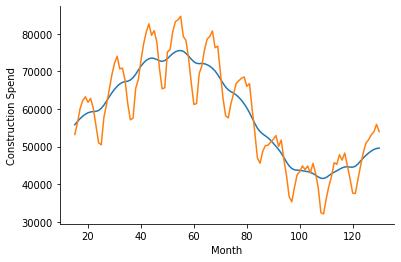

```python
def sqErr(row):
    return(row['homeSales'] - row['MovAvg'])**2
dfCon['MovAvg'] = np.NaN
dfCon['sqErr'] = np.NaN


window = 28
window = window - window % 2
for i in range(int(window/2), dfCon.shape[0]-int(window/2)):
    dfCon.loc[dfCon.index[i],'MovAvg'] = (0.5*dfCon.iloc[i - int(window/2)]['Private Construction'] + dfCon.iloc[i - int(window/2)+1:i + int(window/2)]['Private Construction'].sum() + 0.5*dfCon.iloc[i + int(window/2)]['Private Construction'])/float(window)

dfCon['sqErr'] = (dfCon['Private Construction'] - dfCon['MovAvg'])**2

dfCon.dropna(how='any', inplace=True)

fig, ax = plt.subplots()
ax.plot(dfCon['MovAvg'],label='Moving Avg.')
ax.plot(dfCon['Private Construction'],label='Private Construction Spend')
ax.set_xlabel('Month')
ax.set_ylabel('Construction Spend')
ax.spines['right'].set_visible(False)
ax.spines['top'].set_visible(False)
print('Average Squared Error per Month: ',sum(dfCon['sqErr'])/len(dfCon))
print(dfCon)
```

### Part 1, Step 3: Find the first remainder after removing the moving average

```python
dfCon['R1Private'] = dfCon['Private Construction'] - dfCon['MovAvg']
dfCon['R1ErrorPrivate'] = abs((dfCon['Private Construction']- dfCon['R1Private'])/dfCon['Private Construction'])
dfCon.style.format({
    'MovAvg': '{:,.0f}'.format,
    'sqErr': '{:,.0f}'.format,
    'R1Private': '{:,.0f}'.format,
    'R1ErrorPrivate': '{:,.3f}'.format
})
```

|  | Month | Month-Year | Total Construction | Private Construction | Public Construction | MovAvg | sqErr | R1Private | R1ErrorPrivate |
| --- | --- | --- | --- | --- | --- | --- | --- | --- | --- |
| 15 | 16 | Apr-03 | 69638 | 53195 | 16444 | 55,795 | 6,757,586 | -2,600 | 1.049 |
| 16 | 17 | May-03 | 74473 | 56286 | 18187 | 56,640 | 125,215 | -354 | 1.006 |
| 17 | 18 | Jun-03 | 80377 | 60076 | 20301 | 57,416 | 7,072,940 | 2,660 | 0.956 |
| 18 | 19 | Jul-03 | 82971 | 62216 | 20755 | 58,066 | 17,222,648 | 4,150 | 0.933 |
| 19 | 20 | Aug-03 | 85191 | 63234 | 21957 | 58,579 | 21,672,516 | 4,655 | 0.926 |
| 20 | 21 | Sep-03 | 83841 | 61767 | 22075 | 58,974 | 7,800,350 | 2,793 | 0.955 |
| 21 | 22 | Oct-03 | 83133 | 62813 | 20321 | 59,199 | 13,063,448 | 3,614 | 0.942 |
| 22 | 23 | Nov-03 | 77915 | 60115 | 17801 | 59,295 | 671,610 | 820 | 0.986 |
| 23 | 24 | Dec-03 | 71050 | 55584 | 15466 | 59,357 | 14,235,529 | -3,773 | 1.068 |
| 24 | 25 | Jan-04 | 64934 | 50975 | 13959 | 59,596 | 74,320,717 | -8,621 | 1.169 |
| 25 | 26 | Feb-04 | 64138 | 50449 | 13689 | 60,162 | 94,335,431 | -9,713 | 1.193 |
| 26 | 27 | Mar-04 | 73238 | 57796 | 15443 | 61,004 | 10,293,899 | -3,208 | 1.056 |
| 27 | 28 | Apr-04 | 78354 | 61177 | 17177 | 62,076 | 808,779 | -899 | 1.015 |
| 28 | 29 | May-04 | 83736 | 65027 | 18709 | 63,204 | 3,325,152 | 1,824 | 0.972 |
| 29 | 30 | Jun-04 | 89932 | 69039 | 20893 | 64,273 | 22,710,331 | 4,766 | 0.931 |
| 30 | 31 | Jul-04 | 93614 | 72170 | 21444 | 65,215 | 48,370,535 | 6,955 | 0.904 |
| 31 | 32 | Aug-04 | 96164 | 74001 | 22164 | 66,002 | 63,990,857 | 7,999 | 0.892 |
| 32 | 33 | Sep-04 | 92538 | 70662 | 21876 | 66,650 | 16,097,577 | 4,012 | 0.943 |
| 33 | 34 | Oct-04 | 90582 | 70856 | 19726 | 67,061 | 14,403,380 | 3,795 | 0.946 |
| 34 | 35 | Nov-04 | 86394 | 67585 | 18809 | 67,258 | 107,069 | 327 | 0.995 |
| 35 | 36 | Dec-04 | 77733 | 61438 | 16295 | 67,372 | 35,209,177 | -5,934 | 1.097 |
| 36 | 37 | Jan-05 | 71474 | 57094 | 14380 | 67,691 | 112,288,083 | -10,597 | 1.186 |
| 37 | 38 | Feb-05 | 72048 | 57531 | 14517 | 68,320 | 116,401,750 | -10,789 | 1.188 |
| 38 | 39 | Mar-05 | 81345 | 65425 | 15920 | 69,208 | 14,308,252 | -3,783 | 1.058 |
| 39 | 40 | Apr-05 | 85485 | 67829 | 17656 | 70,319 | 6,202,146 | -2,490 | 1.037 |
| 40 | 41 | May-05 | 92959 | 72862 | 20097 | 71,367 | 2,235,773 | 1,495 | 0.979 |
| 41 | 42 | Jun-05 | 99632 | 77258 | 22375 | 72,248 | 25,095,448 | 5,010 | 0.935 |
| 42 | 43 | Jul-05 | 103158 | 80480 | 22679 | 72,922 | 57,124,714 | 7,558 | 0.906 |
| 43 | 44 | Aug-05 | 106706 | 82629 | 24078 | 73,340 | 86,289,502 | 9,289 | 0.888 |
| 44 | 45 | Sep-05 | 103269 | 79584 | 23685 | 73,526 | 36,694,388 | 6,058 | 0.924 |

[output cut: 86 more lines]

##### Plotting the first remainder to see if cyclicality makes sense as the next step

```
Average Residual:  218.60344827586204
```

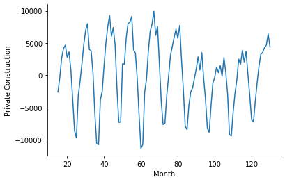

```python
fig, ax = plt.subplots()
ax.plot(dfCon['R1Private'])
ax.set_xlabel('Month')
ax.set_ylabel('Private Construction')
ax.spines['right'].set_visible(False)
ax.spines['top'].set_visible(False)
print('Average Residual: ', sum(dfCon['R1Private']/len(dfCon)))
```

The data looks very cyclical, repeating every several months

### Part 1, Step 4: Find the appropriate lag time to plot seasonality trend

I looked at all potential lag values between 1 and 65, which is about half way through the data set, because I didn't want to get something too high for a lag that wouldn't make sense

```python
maxc = 0.0
period = np.NaN
for i in range(1,65):
    corr = dfCon['R1Private'].autocorr(lag=i)
    print('Correlation, lag ',i,'   ',corr)
    if corr > maxc:
        maxc = corr
        period = i
print('period = ',period,'      Maximum Corrilation = ',maxc)
```

```
Correlation, lag  1     0.8062807744375972
Correlation, lag  2     0.4501406402078271
Correlation, lag  3     0.02600285273108354
Correlation, lag  4     -0.335152666466846
Correlation, lag  5     -0.5919542506878739
Correlation, lag  6     -0.7254740001841741
Correlation, lag  7     -0.6249042183838908
Correlation, lag  8     -0.3972300734842924
Correlation, lag  9     -0.06306097973218303
Correlation, lag  10     0.34232960817337194
Correlation, lag  11     0.6988349588871993
Correlation, lag  12     0.892983029444538
Correlation, lag  13     0.7181073117126496
Correlation, lag  14     0.389186611908261
Correlation, lag  15     -0.01106452811717989
Correlation, lag  16     -0.3528550002020931
Correlation, lag  17     -0.5937686695679367
Correlation, lag  18     -0.7188707239215613
Correlation, lag  19     -0.6183662736183443
Correlation, lag  20     -0.40767720065130597
Correlation, lag  21     -0.09516578095712185
Correlation, lag  22     0.296736352199602
Correlation, lag  23     0.6578254942662983
Correlation, lag  24     0.8498725906215095
Correlation, lag  25     0.6843219548309124
Correlation, lag  26     0.36261136318092285
Correlation, lag  27     -0.03232631698115979
Correlation, lag  28     -0.370631260157211
Correlation, lag  29     -0.609673519209482
Correlation, lag  30     -0.7348741583430808
Correlation, lag  31     -0.6389428355646056
Correlation, lag  32     -0.43023808123619317
Correlation, lag  33     -0.11399963245296205
Correlation, lag  34     0.26693226394079395
Correlation, lag  35     0.6096673702129546
Correlation, lag  36     0.8007942002855293
Correlation, lag  37     0.6580846082361691
Correlation, lag  38     0.35371834021986
Correlation, lag  39     -0.03307501698023613
Correlation, lag  40     -0.38229760947467656
```

[output cut: 10 more lines]

```
Correlation, lag  51     0.0981590578219621
Correlation, lag  52     -0.25344698191347226
Correlation, lag  53     -0.5407392667377022
Correlation, lag  54     -0.7325190338726753
Correlation, lag  55     -0.7069964254460928
Correlation, lag  56     -0.5480512844207338
Correlation, lag  57     -0.25265367107553166
Correlation, lag  58     0.13501025596847974
Correlation, lag  59     0.54426811359812
Correlation, lag  60     0.8182061039834292
Correlation, lag  61     0.753217310315949
Correlation, lag  62     0.5079839668453414
Correlation, lag  63     0.1658187968604945
Correlation, lag  64     -0.1878014965214587
period =  12       Maximum Corrilation =  0.892983029444538
```

##### Coincidentally, I got 12 months as my lag, which means the seasonality repeats annually. Below I graphed each of the cycles from the remaining data compared to the average of all of the cycles and they all follow a similar shape

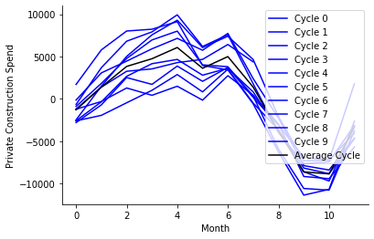

```python
period = 12
cycleLen = period
numCycles = int(len(dfCon)/cycleLen + 0.5)
cycles = [dfCon.iloc[range(i*period,min((i+1)*period,len(dfCon)))]['R1Private'] for i in range(numCycles)]
ptsInCycles = [dfCon.iloc[range(i,len(dfCon['R1Private']),period)]['R1Private'].tolist() for i in range(period)]
avg = [sum(pts)/len(pts) for pts in ptsInCycles]

fig, ax = plt.subplots()
for i in range(len(cycles)):
    ax.plot(cycles[i].values,label='Cycle '+str(i), c='b')
ax.plot(avg,label='Average Cycle', c='k')
ax.set_xlabel('Month')
ax.set_ylabel('Private Construction Spend')
ax.spines['right'].set_visible(False)
ax.spines['top'].set_visible(False)
ax.legend()
```

Adding a new column for cyclicality and adding that into the Data Frame and seeing how it relates to the remainder I am extracting from

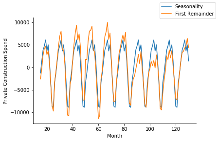

```python
cycleLen = period
numCycles = int(len(dfCon)/cycleLen + 0.5)
dfCon['C'] = np.NaN
for i in range(len(dfCon)):
    dfCon.loc[dfCon.index[i], 'C'] = avg[i % cycleLen]

fig, ax = plt.subplots()
ax.plot(dfCon['C'], label='Seasonality')
ax.plot(dfCon['R1Private'], label = 'First Remainder')
ax.set_xlabel('Month')
ax.set_ylabel('Private Construction Spend')
ax.spines['right'].set_visible(False)
ax.spines['top'].set_visible(False)
fig.legend()
```

##### Based on the above plot, my second remainder term appears to be relatively small

```python
dfCon['R2Private'] = dfCon['R1Private'] - dfCon['C']
dfCon['R2ErrorPrivate'] = abs(dfCon['R2Private']/dfCon['Private Construction'])
dfCon['PrivateEstimate'] = dfCon['MovAvg'] + dfCon['C']
print('Average Error: ', sum(dfCon['R2ErrorPrivate'])/len(dfCon))
dfCon['sqErrPrivate'] = np.NaN
dfCon['sqErrPrivate'] = (dfCon['Private Construction'] - dfCon['PrivateEstimate'])**2
dfCon['cumErrPrivate'] = np.NaN
dfCon['cumErrPrivate'] = dfCon['sqErrPrivate'].cumsum()

print(dfCon)
```

```
Average Error:  0.028972307482198895
     Month Month-Year  Total Construction  Private Construction  \
15      16     Apr-03               69638                 53195
16      17     May-03               74473                 56286
17      18     Jun-03               80377                 60076
18      19     Jul-03               82971                 62216
19      20     Aug-03               85191                 63234
..     ...        ...                 ...                   ...
126    127     Jul-12               78897                 51794
127    128     Aug-12               81712                 53073
128    129     Sep-12               80812                 53874
129    130     Oct-12               81520                 55888
130    131     Nov-12               77091                 53942

     Public Construction        MovAvg         sqErr    R1Private  \
```

[output cut: 39 more lines]

##### Average R2 error is 2.9%, so my assumption is correct!

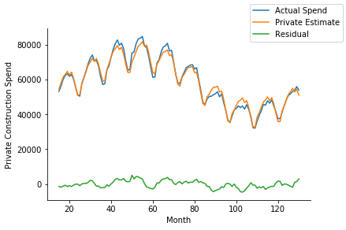

```python
fig,ax = plt.subplots()
ax.plot(dfCon['Private Construction'],label='Actual Spend')
ax.plot(dfCon['PrivateEstimate'], label = 'Private Estimate')
ax.plot(dfCon['R2Private'], label='Residual')
ax.set_xlabel('Month')
ax.set_ylabel('Private Construction Spend')
ax.spines['right'].set_visible(False)
ax.spines['top'].set_visible(False)
fig.legend()
```

##### Having a final look at my model for Private Construction spend, along with the actual dataset and the residual term

##### Taking a look at other possibilities for seaonality, it looks like the one I chose resulted in the least squared error

```python
for a in [0.1 * i for i in range(1,20)]:
    dfCon['aC'] = a*dfCon['C']
    dfCon['R3'] = dfCon['R1Private'] - dfCon['aC']
    dfCon['sqErr'] = dfCon['R3']**2
    print('Squared Error for a =','{:.1f}'.format(a),':',sum(dfCon['sqErr']))
```

```
Squared Error for a = 0.1 : 2738566873.854615
Squared Error for a = 0.2 : 2265590423.044886
Squared Error for a = 0.3 : 1848258260.5657165
Squared Error for a = 0.4 : 1486570386.4171026
Squared Error for a = 0.5 : 1180526800.599043
Squared Error for a = 0.6 : 930127503.1115408
Squared Error for a = 0.7 : 735372493.9545944
Squared Error for a = 0.8 : 596261773.1282039
Squared Error for a = 0.9 : 512795340.63237
Squared Error for a = 1.0 : 484973196.46709204
Squared Error for a = 1.1 : 512795340.63237023
Squared Error for a = 1.2 : 596261773.1282043
Squared Error for a = 1.3 : 735372493.9545946
Squared Error for a = 1.4 : 930127503.1115412
Squared Error for a = 1.5 : 1180526800.5990434
Squared Error for a = 1.6 : 1486570386.4171026
Squared Error for a = 1.7 : 1848258260.5657167
Squared Error for a = 1.8 : 2265590423.044887
Squared Error for a = 1.9 : 2738566873.8546147
```

### Part 2, Step 2: Finding the trend of the Public data

Based on the below plot, I would assume that a moving average method would again work better than a linear trend because of the shape of the graph

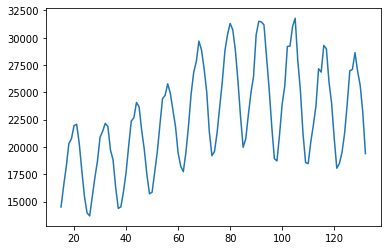

```python
plt.plot(dfCon.Month,dfCon['Public Construction'])
```

##### Testing what window size would work best

```python
dfTest2 = dfCon
def sqErr(row):
        return(row['Public Construction'] - row['MovAvg'])**2
dfTest['MovAvg'] = np.NaN
dfTest['sqErr'] = np.NaN

for j in range(2,72):
    window = j
    window = window - window % 2
    for i in range(int(window/2), dfTest.shape[0]-int(window/2)):
        dfTest.loc[dfTest.index[i],'MovAvg'] = (0.5*dfTest.iloc[i - int(window/2)]['Public Construction'] + dfTest.iloc[i - int(window/2)+1:i + int(window/2)]['Public Construction'].sum() + 0.5*dfTest.iloc[i + int(window/2)]['Public Construction'])/float(window)

    dfTest['sqErr'] = (dfTest['Public Construction'] - dfTest['MovAvg'])**2

    dfTest.dropna(how='any', inplace=True)

    print('Window = ',j,'Average Squared Error per Month: ',sum(dfTest['sqErr'])/len(dfTest))
```

```
Window =  2 Average Squared Error per Month:  158702.1913377193
Window =  3 Average Squared Error per Month:  158702.1913377193
Window =  4 Average Squared Error per Month:  697213.545504386
Window =  5 Average Squared Error per Month:  697213.545504386
Window =  6 Average Squared Error per Month:  2087139.3500395953
Window =  7 Average Squared Error per Month:  2087139.3500395953
Window =  8 Average Squared Error per Month:  4718393.387876157
Window =  9 Average Squared Error per Month:  4718393.387876157
Window =  10 Average Squared Error per Month:  8347544.329064482
Window =  11 Average Squared Error per Month:  8347544.329064482
Window =  12 Average Squared Error per Month:  12294550.148700196
Window =  13 Average Squared Error per Month:  12294550.148700196
Window =  14 Average Squared Error per Month:  15615307.84990603
Window =  15 Average Squared Error per Month:  15615307.84990603
Window =  16 Average Squared Error per Month:  17499497.18435246
Window =  17 Average Squared Error per Month:  17499497.18435246
Window =  18 Average Squared Error per Month:  17696170.100424554
Window =  19 Average Squared Error per Month:  17696170.100424554
Window =  20 Average Squared Error per Month:  16570323.785253724
Window =  21 Average Squared Error per Month:  16570323.785253724
Window =  22 Average Squared Error per Month:  14762576.356759902
Window =  23 Average Squared Error per Month:  14762576.356759902
Window =  24 Average Squared Error per Month:  12878393.373799851
Window =  25 Average Squared Error per Month:  12878393.373799851
Window =  26 Average Squared Error per Month:  11407618.978689855
Window =  27 Average Squared Error per Month:  11407618.978689855
Window =  28 Average Squared Error per Month:  10590694.954239927
Window =  29 Average Squared Error per Month:  10590694.954239927
Window =  30 Average Squared Error per Month:  10429617.460628022
Window =  31 Average Squared Error per Month:  10429617.460628022
Window =  32 Average Squared Error per Month:  10828886.195241535
Window =  33 Average Squared Error per Month:  10828886.195241535
Window =  34 Average Squared Error per Month:  11624843.68051384
Window =  35 Average Squared Error per Month:  11624843.68051384
Window =  36 Average Squared Error per Month:  12620449.273277134
Window =  37 Average Squared Error per Month:  12620449.273277134
Window =  38 Average Squared Error per Month:  13565741.833122147
Window =  39 Average Squared Error per Month:  13565741.833122147
Window =  40 Average Squared Error per Month:  14208834.568233728
Window =  41 Average Squared Error per Month:  14208834.568233728
```

[output cut: 15 more lines]

```
Window =  57 Average Squared Error per Month:  12268837.562651237
Window =  58 Average Squared Error per Month:  12609563.903900944
Window =  59 Average Squared Error per Month:  12609563.903900944
Window =  60 Average Squared Error per Month:  13043303.738521913
Window =  61 Average Squared Error per Month:  13043303.738521913
Window =  62 Average Squared Error per Month:  13469046.098224783
Window =  63 Average Squared Error per Month:  13469046.098224783
Window =  64 Average Squared Error per Month:  13779724.849362215
Window =  65 Average Squared Error per Month:  13779724.849362215
Window =  66 Average Squared Error per Month:  13913373.609399427
Window =  67 Average Squared Error per Month:  13913373.609399427
Window =  68 Average Squared Error per Month:  13883003.163189339
Window =  69 Average Squared Error per Month:  13883003.163189339
Window =  70 Average Squared Error per Month:  13740535.814924026
Window =  71 Average Squared Error per Month:  13740535.814924026
```

```
Average Squared Error per Month:  10908843.535591934
     Month Month-Year  Total Construction  Private Construction  \
31      32     Aug-04               96164                 74001
32      33     Sep-04               92538                 70662
33      34     Oct-04               90582                 70856
34      35     Nov-04               86394                 67585
35      36     Dec-04               77733                 61438
..     ...        ...                 ...                   ...
110    111     Mar-11               56536                 36074
111    112     Apr-11               61454                 39441
112    113     May-11               65814                 42040
113    114     Jun-11               72850                 45686
114    115     Jul-11               72113                 45258

     Public Construction        MovAvg         sqErr    R1Private  \
```

[output cut: 52 more lines]

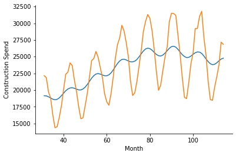

```python
def sqErr(row):
    return(row['Public Construction'] - row['MovAvg2'])**2
dfCon['MovAvg2'] = np.NaN
dfCon['sqErr2'] = np.NaN


window = 30
window = window - window % 2
for i in range(int(window/2), dfCon.shape[0]-int(window/2)):
    dfCon.loc[dfCon.index[i],'MovAvg2'] = (0.5*dfCon.iloc[i - int(window/2)]['Public Construction'] + dfCon.iloc[i - int(window/2)+1:i + int(window/2)]['Public Construction'].sum() + 0.5*dfCon.iloc[i + int(window/2)]['Public Construction'])/float(window)

dfCon['sqErr2'] = (dfCon['Public Construction'] - dfCon['MovAvg2'])**2

dfCon.dropna(how='any', inplace=True)

fig, ax = plt.subplots()
ax.plot(dfCon['MovAvg2'],label='Moving Avg.')
ax.plot(dfCon['Public Construction'],label='Public Construction Spend')
ax.set_xlabel('Month')
ax.set_ylabel('Construction Spend')
ax.spines['right'].set_visible(False)
ax.spines['top'].set_visible(False)
print('Average Squared Error per Month: ',sum(dfCon['sqErr2'])/len(dfCon))
print(dfCon)
```

This moving average fits better than any linear approximation would, so I am happy with my decision to choose it

### Part 2, Step 3: Find the first remainder after removing the moving average

```python
dfCon['R1Public'] = dfCon['Public Construction'] - dfCon['MovAvg2']
dfCon['R1ErrorPublic'] = abs((dfCon['Public Construction']- dfCon['R1Public'])/dfCon['Public Construction'])
dfCon.style.format({
    'MovAvg2': '{:,.0f}'.format,
    'sqErr2': '{:,.0f}'.format,
    'R1Public': '{:,.0f}'.format,
    'R1ErrorPublic': '{:,.3f}'.format
})
```

|  | Month | Month-Year | Total Construction | Private Construction | Public Construction | MovAvg | sqErr | R1Private | R1ErrorPrivate | C | R2Private | R2ErrorPrivate | PrivateEstimate | sqErrPrivate | cumErrPrivate | aC | R3 | MovAvg2 | sqErr2 | R1Public | R1ErrorPublic |
| --- | --- | --- | --- | --- | --- | --- | --- | --- | --- | --- | --- | --- | --- | --- | --- | --- | --- | --- | --- | --- | --- |
| 31 | 32 | Aug-04 | 96164 | 74001 | 22164 | 19158.233333 | 9034633.254444 | 7999.428571 | 0.891901 | 6063.992857 | 1935.435714 | 0.026154 | 72065.564286 | 3745911.404133 | 21928135.069731 | 11521.586429 | -3522.157857 | 19,158 | 9,034,633 | 3,006 | 0.864 |
| 32 | 33 | Sep-04 | 92538 | 70662 | 21876 | 19061.656250 | 7920530.743164 | 4012.178571 | 0.943220 | 3611.912500 | 400.266071 | 0.005665 | 70261.733929 | 160212.927937 | 22088347.997668 | 6862.633750 | -2850.455179 | 19,138 | 7,498,469 | 2,738 | 0.875 |
| 33 | 34 | Oct-04 | 90582 | 70856 | 19726 | 18898.102941 | 685413.540009 | 3795.178571 | 0.946438 | 4988.610714 | -1193.432143 | 0.016843 | 72049.432143 | 1424280.279605 | 23512628.277273 | 9478.360357 | -5683.181786 | 19,007 | 517,392 | 719 | 0.964 |
| 34 | 35 | Nov-04 | 86394 | 67585 | 18809 | 18942.472222 | 17814.834105 | 327.214286 | 0.995158 | 1385.458929 | -1058.244643 | 0.015658 | 68643.244643 | 1119881.724136 | 24632510.001409 | 2632.371964 | -2305.157679 | 18,821 | 146 | -12 | 1.001 |
| 35 | 36 | Dec-04 | 77733 | 61438 | 16295 | 19202.763158 | 8455086.582410 | -5933.732143 | 1.096581 | -3789.263889 | -2144.468254 | 0.034905 | 63582.468254 | 4598744.092278 | 29231254.093686 | -7199.601389 | 1265.869246 | 18,646 | 5,529,004 | -2,351 | 1.144 |
| 36 | 37 | Jan-05 | 71474 | 57094 | 14380 | 19507.825000 | 26294589.230625 | -10596.607143 | 1.185599 | -8635.359127 | -1961.248016 | 0.034351 | 59055.248016 | 3846493.779766 | 33077747.873452 | -16407.182341 | 5810.575198 | 18,560 | 17,475,605 | -4,180 | 1.291 |
| 37 | 38 | Feb-05 | 72048 | 57531 | 14517 | 19692.797619 | 26788880.993339 | -10788.964286 | 1.187533 | -8871.011905 | -1917.952381 | 0.033338 | 59448.952381 | 3678541.335601 | 36756289.209053 | -16854.922619 | 6065.958333 | 18,618 | 16,814,374 | -4,101 | 1.282 |
| 38 | 39 | Mar-05 | 81345 | 65425 | 15920 | 19695.977273 | 14258004.364153 | -3782.625000 | 1.057816 | -3339.853175 | -442.771825 | 0.006768 | 65867.771825 | 196046.889365 | 36952336.098418 | -6345.721032 | 2563.096032 | 18,837 | 8,507,236 | -2,917 | 1.183 |
| 39 | 40 | Apr-05 | 85485 | 67829 | 17656 | 19635.586957 | 3918764.518431 | -2490.410714 | 1.036716 | -1295.521429 | -1194.889286 | 0.017616 | 69023.889286 | 1427760.405115 | 38380096.503533 | -2461.490714 | -28.920000 | 19,165 | 2,277,685 | -1,509 | 1.085 |
| 40 | 41 | May-05 | 92959 | 72862 | 20097 | 19736.562500 | 129915.191406 | 1495.250000 | 0.979478 | 1388.075000 | 107.175000 | 0.001471 | 72754.825000 | 11486.480625 | 38391582.984158 | 2637.342500 | -1142.092500 | 19,546 | 303,381 | 551 | 0.973 |
| 41 | 42 | Jun-05 | 99632 | 77258 | 22375 | 20010.530000 | 5590718.380900 | 5009.535714 | 0.935158 | 3828.973214 | 1180.562500 | 0.015281 | 76077.437500 | 1393727.816406 | 39785310.800564 | 7275.049107 | -2265.513393 | 19,906 | 6,096,949 | 2,469 | 0.890 |
| 42 | 43 | Jul-05 | 103158 | 80480 | 22679 | 20357.019231 | 5391594.692678 | 7558.089286 | 0.906087 | 4736.237500 | 2821.851786 | 0.035063 | 77658.148214 | 7962847.500539 | 47748158.301103 | 8998.851250 | -1440.761964 | 20,167 | 6,308,888 | 2,512 | 0.889 |
| 43 | 44 | Aug-05 | 106706 | 82629 | 24078 | 20605.092593 | 12061085.860425 | 9289.214286 | 0.887579 | 6063.992857 | 3225.221429 | 0.039033 | 79403.778571 | 10402053.263316 | 58150211.564420 | 11521.586429 | -2232.372143 | 20,324 | 14,096,145 | 3,754 | 0.844 |
| 44 | 45 | Sep-05 | 103269 | 79584 | 23685 | 20645.964286 | 9235738.072704 | 6057.589286 | 0.923884 | 3611.912500 | 2445.676786 | 0.030731 | 77138.323214 | 5981334.940182 | 64131546.504601 | 6862.633750 | -805.044464 | 20,353 | 11,105,445 | 3,332 | 0.859 |
| 45 | 46 | Oct-05 | 102339 | 80820 | 21519 | 20621.439655 | 805614.572607 | 7396.053571 | 0.908487 | 4988.610714 | 2407.442857 | 0.029788 | 78412.557143 | 5795781.110408 | 69927327.615009 | 9478.360357 | -2082.306786 | 20,275 | 1,546,582 | 1,244 | 0.942 |
| 46 | 47 | Nov-05 | 97549 | 77774 | 19775 | 20723.508333 | 899668.058403 | 4645.232143 | 0.940273 | 1385.458929 | 3259.773214 | 0.041913 | 74514.226786 | 10626121.408575 | 80553449.023584 | 2632.371964 | 2012.860179 | 20,148 | 139,378 | -373 | 1.019 |
| 47 | 48 | Dec-05 | 88172 | 70692 | 17479 | 20974.064516 | 12215475.971904 | -2098.910714 | 1.029691 | -3789.263889 | 1690.353175 | 0.023912 | 69001.646825 | 2857293.854891 | 83410742.878475 | -7199.601389 | 5100.690675 | 20,035 | 6,533,392 | -2,556 | 1.146 |
| 48 | 49 | Jan-06 | 81058 | 65339 | 15719 | 21284.750000 | 30977573.062500 | -7316.178571 | 1.111973 | -8635.359127 | 1319.180556 | 0.020190 | 64019.819444 | 1740237.338156 | 85150980.216631 | -16407.182341 | 9091.003770 | 20,032 | 18,605,707 | -4,313 | 1.274 |
| 49 | 50 | Feb-06 | 81478 | 65622 | 15857 | 21507.803030 | 31931574.887282 | -7244.125000 | 1.110392 | -8871.011905 | 1626.886905 | 0.024792 | 63995.113095 | 2646761.000886 | 87797741.217517 | -16854.922619 | 9610.797619 | 20,170 | 18,602,257 | -4,313 | 1.272 |
| 50 | 51 | Mar-06 | 92855 | 75163 | 17692 | 21548.500000 | 14872592.250000 | 1786.410714 | 0.976233 | -3339.853175 | 5126.263889 | 0.068202 | 70036.736111 | 26278581.458526 | 114076322.676043 | -6345.721032 | 8132.131746 | 20,446 | 7,586,719 | -2,754 | 1.156 |
| 51 | 52 | Apr-06 | 95324 | 75780 | 19544 | 21535.707143 | 3966897.342908 | 1695.875000 | 0.977621 | -1295.521429 | 2991.396429 | 0.039475 | 72788.603571 | 8948452.592870 | 123024775.268913 | -2461.490714 | 4157.365714 | 20,846 | 1,695,464 | -1,302 | 1.067 |
| 52 | 53 | May-06 | 102495 | 80488 | 22007 | 21602.857143 | 163331.448980 | 5781.089286 | 0.928175 | 1388.075000 | 4393.014286 | 0.054580 | 76094.985714 | 19298574.514490 | 142323349.783403 | 2637.342500 | 3143.746786 | 21,323 | 467,810 | 684 | 0.969 |
| 53 | 54 | Jun-06 | 107607 | 83196 | 24411 | 21676.878571 | 7475419.986173 | 8011.357143 | 0.903705 | 3828.973214 | 4182.383929 | 0.050271 | 79013.616071 | 17492335.325973 | 159815685.109375 | 7275.049107 | 736.308036 | 21,792 | 6,860,121 | 2,619 | 0.893 |
| 54 | 55 | Jul-06 | 108423 | 83700 | 24723 | 21776.971429 | 8679084.343673 | 8223.857143 | 0.901746 | 4736.237500 | 3487.619643 | 0.041668 | 80212.380357 | 12163490.773243 | 171979175.882618 | 8998.851250 | -774.994107 | 22,166 | 6,538,590 | 2,557 | 0.897 |
| 55 | 56 | Aug-06 | 110434 | 84649 | 25785 | 21903.642857 | 15064933.270408 | 9121.910714 | 0.892238 | 6063.992857 | 3057.917857 | 0.036125 | 81591.082143 | 9350861.621033 | 181330037.503652 | 11521.586429 | -2399.675714 | 22,407 | 11,413,136 | 3,378 | 0.869 |
| 56 | 57 | Sep-06 | 104191 | 79268 | 24923 | 22050.507143 | 8251215.214337 | 3942.089286 | 0.950269 | 3611.912500 | 330.176786 | 0.004165 | 78937.823214 | 109016.709825 | 181439054.213476 | 6862.633750 | -2920.544464 | 22,472 | 6,004,950 | 2,450 | 0.902 |
| 57 | 58 | Oct-06 | 101582 | 78199 | 23384 | 22225.621429 | 1341840.914745 | 3417.589286 | 0.956296 | 4988.610714 | -1571.021429 | 0.020090 | 79770.021429 | 2468108.329031 | 183907162.542507 | 9478.360357 | -6060.771071 | 22,398 | 972,459 | 986 | 0.958 |
| 58 | 59 | Nov-06 | 95339 | 73461 | 21878 | 22412.342857 | 285522.288980 | -584.285714 | 1.007954 | 1385.458929 | -1969.744643 | 0.026813 | 75430.744643 | 3879893.958064 | 187787056.500571 | 2632.371964 | -3216.657679 | 22,265 | 149,975 | -387 | 1.018 |
| 59 | 60 | Dec-06 | 86436 | 66972 | 19464 | 22584.507143 | 9737564.828622 | -6276.339286 | 1.093716 | -3789.263889 | -2487.075397 | 0.037136 | 69459.075397 | 6185544.029494 | 193972600.530065 | -7199.601389 | 923.262103 | 22,152 | 7,222,746 | -2,688 | 1.138 |
| 60 | 61 | Jan-07 | 79406 | 61161 | 18245 | 22724.142857 | 20062720.734694 | -11381.500000 | 1.186091 | -8635.359127 | -2746.140873 | 0.044900 | 63907.140873 | 7541289.694448 | 201513890.224514 | -16407.182341 | 5025.682341 | 22,149 | 15,237,963 | -3,904 | 1.214 |

[output cut: 54 more lines]

##### Plotting the first remainder, seeing if cyclicality makes sense as a next step

```
Average Residual:  34.78353174603191
```

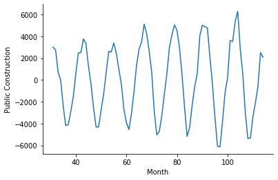

```python
fig, ax = plt.subplots()
ax.plot(dfCon['R1Public'])
ax.set_xlabel('Month')
ax.set_ylabel('Public Construction')
ax.spines['right'].set_visible(False)
ax.spines['top'].set_visible(False)
print('Average Residual: ', sum(dfCon['R1Public']/len(dfCon)))
```

### Part 2, Step 4: Finding Cyclicality

I used a slightly smaller range to find the correct lag in the data, assuming it could also be 12 like the private data

```python
maxc = 0.0
period = np.NaN
for i in range(1,50):
    corr = dfCon['R1Public'].autocorr(lag=i)
    print('Correlation, lag ',i,'   ',corr)
    if corr > maxc:
        maxc = corr
        period = i
print('period = ',period,'      Maximum Corrilation = ',maxc)
```

```
Correlation, lag  1     0.8432798822975164
Correlation, lag  2     0.47404112957133104
Correlation, lag  3     -0.002193124266408041
Correlation, lag  4     -0.47754881439721836
Correlation, lag  5     -0.808998885322661
Correlation, lag  6     -0.9382319953224755
Correlation, lag  7     -0.8315242054768301
Correlation, lag  8     -0.49732201550985183
Correlation, lag  9     -0.016683487776538202
Correlation, lag  10     0.44969558694001377
Correlation, lag  11     0.8117013912152239
Correlation, lag  12     0.9751903512692991
Correlation, lag  13     0.8428356874758512
Correlation, lag  14     0.48982770094806544
Correlation, lag  15     0.013438481173831403
Correlation, lag  16     -0.4563203878526107
Correlation, lag  17     -0.7887741985741796
Correlation, lag  18     -0.9286749135152177
Correlation, lag  19     -0.8342132087659222
Correlation, lag  20     -0.5028333658142136
Correlation, lag  21     -0.025261526374194043
Correlation, lag  22     0.44714029422311763
Correlation, lag  23     0.8087605060717399
Correlation, lag  24     0.9653076930049541
Correlation, lag  25     0.8418203879688986
Correlation, lag  26     0.4821370439939241
Correlation, lag  27     0.0005813438650958332
Correlation, lag  28     -0.47317208098890856
Correlation, lag  29     -0.8105828671885523
Correlation, lag  30     -0.9457399869150601
Correlation, lag  31     -0.850197395327689
Correlation, lag  32     -0.5180856621818313
Correlation, lag  33     -0.04434456550668194
Correlation, lag  34     0.4324937780087328
Correlation, lag  35     0.7948235246388698
Correlation, lag  36     0.9680199218952511
Correlation, lag  37     0.8586372720731068
Correlation, lag  38     0.49725921921845023
Correlation, lag  39     0.020518168046733724
Correlation, lag  40     -0.4518769215982519
Correlation, lag  41     -0.7883691698524821
Correlation, lag  42     -0.9353315057372055
Correlation, lag  43     -0.8505000659585776
Correlation, lag  44     -0.5281836851018945
Correlation, lag  45     -0.05689840337744834
Correlation, lag  46     0.4213123344149806
Correlation, lag  47     0.7702189099885957
Correlation, lag  48     0.9583900436427292
Correlation, lag  49     0.8587246376222276
period =  12       Maximum Corrilation =  0.9751903512692991
```

##### Using a 12 month lag again, this correlation is extremely high

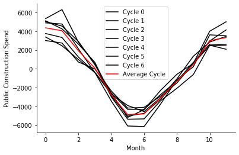

```python
period = 12
cycleLen = period
numCycles = int(len(dfCon)/cycleLen + 0.5)
cycles = [dfCon.iloc[range(i*period,min((i+1)*period,len(dfCon)))]['R1Public'] for i in range(numCycles)]
ptsInCycles = [dfCon.iloc[range(i,len(dfCon['R1Public']),period)]['R1Public'].tolist() for i in range(period)]
avg = [sum(pts)/len(pts) for pts in ptsInCycles]

fig, ax = plt.subplots()
for i in range(len(cycles)):
    ax.plot(cycles[i].values,label='Cycle '+str(i), c='k')
ax.plot(avg,label='Average Cycle', c='r')
ax.set_xlabel('Month')
ax.set_ylabel('Public Construction Spend')
ax.spines['right'].set_visible(False)
ax.spines['top'].set_visible(False)
ax.legend()
```

##### Each cycle looks fairly consistent, with the average a similar shape as well

I am calling cyclicality for Public Construction S for seasonality, so we cna still see both Private and Public in the dataframe

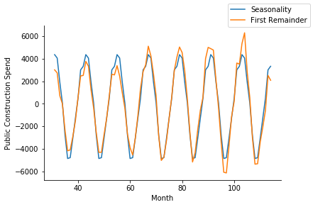

```python
cycleLen = period
numCycles = int(len(dfCon)/cycleLen + 0.5)
dfCon['S'] = np.NaN
for i in range(len(dfCon)):
    dfCon.loc[dfCon.index[i], 'S'] = avg[i % cycleLen]

fig, ax = plt.subplots()
ax.plot(dfCon['S'], label='Seasonality')
ax.plot(dfCon['R1Public'], label = 'First Remainder')
ax.set_xlabel('Month')
ax.set_ylabel('Public Construction Spend')
ax.spines['right'].set_visible(False)
ax.spines['top'].set_visible(False)
fig.legend()
```

##### Our cyclicality fit looks very close to our first remainder term, below I will fact check that with my error term

```python
dfCon['R2Public'] = dfCon['R1Public'] - dfCon['S']
dfCon['R2ErrorPublic'] = abs(dfCon['R2Public']/dfCon['Public Construction'])
dfCon['PublicEstimate'] = dfCon['MovAvg2'] + dfCon['S']
print('Average Error: ', sum(dfCon['R2ErrorPublic'])/len(dfCon))
dfCon['sqErrPublic'] = np.NaN
dfCon['sqErrPublic'] = (dfCon['Public Construction'] - dfCon['PublicEstimate'])**2
dfCon['cumErrPublic'] = np.NaN
dfCon['cumErrPublic'] = dfCon['sqErrPublic'].cumsum()

print(dfCon)
```

```
Average Error:  0.024475101213593996
     Month Month-Year  Total Construction  Private Construction  \
31      32     Aug-04               96164                 74001
32      33     Sep-04               92538                 70662
33      34     Oct-04               90582                 70856
34      35     Nov-04               86394                 67585
35      36     Dec-04               77733                 61438
..     ...        ...                 ...                   ...
110    111     Mar-11               56536                 36074
111    112     Apr-11               61454                 39441
112    113     May-11               65814                 42040
113    114     Jun-11               72850                 45686
114    115     Jul-11               72113                 45258

     Public Construction        MovAvg         sqErr    R1Private  \
```

[output cut: 52 more lines]

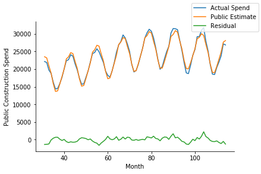

```python
fig,ax = plt.subplots()
ax.plot(dfCon['Public Construction'],label='Actual Spend')
ax.plot(dfCon['PublicEstimate'], label = 'Public Estimate')
ax.plot(dfCon['R2Public'], label='Residual')
ax.set_xlabel('Month')
ax.set_ylabel('Public Construction Spend')
ax.spines['right'].set_visible(False)
ax.spines['top'].set_visible(False)
fig.legend()
```

A final look at my estimate and the actual public spend over the time period I estimated for, as well as my error term

```python
##Checking if other seasonality values would've resulted in a lower squared error
for a in [0.1 * i for i in range(1,20)]:
    dfCon['aS'] = a*dfCon['S']
    dfCon['R3Pub'] = dfCon['R1Public'] - dfCon['aS']
    dfCon['sqErr'] = dfCon['R3Pub']**2
    print('Squared Error for a =','{:.1f}'.format(a),':',sum(dfCon['sqErr']))
```

```
Squared Error for a = 0.1 : 750395750.0103722
Squared Error for a = 0.2 : 601916759.5551652
Squared Error for a = 0.3 : 470905885.6240996
Squared Error for a = 0.4 : 357363128.21717614
Squared Error for a = 0.5 : 261288487.3343948
Squared Error for a = 0.6 : 182681962.9757555
Squared Error for a = 0.7 : 121543555.14125827
Squared Error for a = 0.8 : 77873263.83090311
Squared Error for a = 0.9 : 51671089.04469005
Squared Error for a = 1.0 : 42937030.782619044
Squared Error for a = 1.1 : 51671089.04469007
Squared Error for a = 1.2 : 77873263.83090319
Squared Error for a = 1.3 : 121543555.14125833
Squared Error for a = 1.4 : 182681962.97575554
Squared Error for a = 1.5 : 261288487.3343947
Squared Error for a = 1.6 : 357363128.217176
Squared Error for a = 1.7 : 470905885.62409973
Squared Error for a = 1.8 : 601916759.5551649
Squared Error for a = 1.9 : 750395750.0103724
```

1.0 still yielded the best fit in this case as well

### To conclude, here are 40 rows of my final dataframe after completing the analysis

```python
dfCon.head(n=40)
```

|  | Month | Month-Year | Total Construction | Private Construction | Public Construction | MovAvg | sqErr | R1Private | R1ErrorPrivate | C | ... | R1Public | R1ErrorPublic | S | R2Public | R2ErrorPublic | PublicEstimate | sqErrPublic | cumErrPublic | aS | R3Pub |
| --- | --- | --- | --- | --- | --- | --- | --- | --- | --- | --- | --- | --- | --- | --- | --- | --- | --- | --- | --- | --- | --- |
| 31 | 32 | Aug-04 | 96164 | 74001 | 22164 | 19158.233333 | 2.782867e+07 | 7999.428571 | 0.891901 | 6063.992857 | ... | 3005.766667 | 0.864385 | 4358.450000 | -1352.683333 | 0.061031 | 23516.683333 | 1.829752e+06 | 1.829752e+06 | 8281.055000 | -5275.288333 |
| 32 | 33 | Sep-04 | 92538 | 70662 | 21876 | 19061.656250 | 2.461866e+07 | 4012.178571 | 0.943220 | 3611.912500 | ... | 2738.333333 | 0.874825 | 4052.659524 | -1314.326190 | 0.060081 | 23190.326190 | 1.727453e+06 | 3.557206e+06 | 7700.053095 | -4961.719762 |
| 33 | 34 | Oct-04 | 90582 | 70856 | 19726 | 18898.102941 | 8.567959e+06 | 3795.178571 | 0.946438 | 4988.610714 | ... | 719.300000 | 0.963535 | 1919.161905 | -1199.861905 | 0.060826 | 20925.861905 | 1.439669e+06 | 4.996874e+06 | 3646.407619 | -2927.107619 |
| 34 | 35 | Nov-04 | 86394 | 67585 | 18809 | 18942.472222 | 2.273928e+04 | 327.214286 | 0.995158 | 1385.458929 | ... | -12.100000 | 1.000643 | 72.997619 | -85.097619 | 0.004524 | 18894.097619 | 7.241605e+03 | 5.004116e+06 | 138.695476 | -150.795476 |
| 35 | 36 | Dec-04 | 77733 | 61438 | 16295 | 19202.763158 | 8.534773e+06 | -5933.732143 | 1.096581 | -3789.263889 | ... | -2351.383333 | 1.144301 | -2775.166667 | 423.783333 | 0.026007 | 15871.216667 | 1.795923e+05 | 5.183708e+06 | -5272.816667 | 2921.433333 |
| 36 | 37 | Jan-05 | 71474 | 57094 | 14380 | 19507.825000 | 2.564706e+07 | -10596.607143 | 1.185599 | -8635.359127 | ... | -4180.383333 | 1.290708 | -4865.619048 | 685.235714 | 0.047652 | 13694.764286 | 4.695480e+05 | 5.653256e+06 | -9244.676190 | 5064.292857 |
| 37 | 38 | Feb-05 | 72048 | 57531 | 14517 | 19692.797619 | 2.499024e+07 | -10788.964286 | 1.187533 | -8871.011905 | ... | -4100.533333 | 1.282464 | -4789.240476 | 688.707143 | 0.047441 | 13828.292857 | 4.743175e+05 | 6.127574e+06 | -9099.556905 | 4999.023571 |
| 38 | 39 | Mar-05 | 81345 | 65425 | 15920 | 19695.977273 | 8.492312e+06 | -3782.625000 | 1.057816 | -3339.853175 | ... | -2916.716667 | 1.183211 | -3068.880952 | 152.164286 | 0.009558 | 15767.835714 | 2.315397e+04 | 6.150728e+06 | -5830.873810 | 2914.157143 |
| 39 | 40 | Apr-05 | 85485 | 67829 | 17656 | 19635.586957 | 8.717241e+05 | -2490.410714 | 1.036716 | -1295.521429 | ... | -1509.200000 | 1.085478 | -1285.716667 | -223.483333 | 0.012658 | 17879.483333 | 4.994480e+04 | 6.200672e+06 | -2442.861667 | 933.661667 |
| 40 | 41 | May-05 | 92959 | 72862 | 20097 | 19736.562500 | 1.217342e+05 | 1495.250000 | 0.979478 | 1388.075000 | ... | 550.800000 | 0.972593 | 473.528571 | 77.271429 | 0.003845 | 20019.728571 | 5.970874e+03 | 6.206643e+06 | 899.704286 | -348.904286 |
| 41 | 42 | Jun-05 | 99632 | 77258 | 22375 | 20010.530000 | 1.046624e+07 | 5009.535714 | 0.935158 | 3828.973214 | ... | 2469.200000 | 0.889645 | 3002.292857 | -533.092857 | 0.023825 | 22908.092857 | 2.841880e+05 | 6.490831e+06 | 5704.356429 | -3235.156429 |
| 42 | 43 | Jul-05 | 103158 | 80480 | 22679 | 20357.019231 | 1.445390e+07 | 7558.089286 | 0.906087 | 4736.237500 | ... | 2511.750000 | 0.889248 | 3322.935714 | -811.185714 | 0.035768 | 23490.185714 | 6.580223e+05 | 7.148853e+06 | 6313.577857 | -3801.827857 |
| 43 | 44 | Aug-05 | 106706 | 82629 | 24078 | 20605.092593 | 2.048985e+07 | 9289.214286 | 0.887579 | 6063.992857 | ... | 3754.483333 | 0.844070 | 4358.450000 | -603.966667 | 0.025084 | 24681.966667 | 3.647757e+05 | 7.513629e+06 | 8281.055000 | -4526.571667 |
| 44 | 45 | Sep-05 | 103269 | 79584 | 23685 | 20645.964286 | 1.907567e+07 | 6057.589286 | 0.923884 | 3611.912500 | ... | 3332.483333 | 0.859300 | 4052.659524 | -720.176190 | 0.030406 | 24405.176190 | 5.186537e+05 | 8.032283e+06 | 7700.053095 | -4367.569762 |
| 45 | 46 | Oct-05 | 102339 | 80820 | 21519 | 20621.439655 | 5.773404e+06 | 7396.053571 | 0.908487 | 4988.610714 | ... | 1243.616667 | 0.942208 | 1919.161905 | -675.545238 | 0.031393 | 22194.545238 | 4.563614e+05 | 8.488644e+06 | 3646.407619 | -2402.790952 |
| 46 | 47 | Nov-05 | 97549 | 77774 | 19775 | 20723.508333 | 2.621735e+05 | 4645.232143 | 0.940273 | 1385.458929 | ... | -373.333333 | 1.018879 | 72.997619 | -446.330952 | 0.022570 | 20221.330952 | 1.992113e+05 | 8.687856e+06 | 138.695476 | -512.028810 |
| 47 | 48 | Dec-05 | 88172 | 70692 | 17479 | 20974.064516 | 7.380821e+06 | -2098.910714 | 1.029691 | -3789.263889 | ... | -2556.050000 | 1.146235 | -2775.166667 | 219.116667 | 0.012536 | 17259.883333 | 4.801211e+04 | 8.735868e+06 | -5272.816667 | 2716.766667 |
| 48 | 49 | Jan-06 | 81058 | 65339 | 15719 | 21284.750000 | 2.431716e+07 | -7316.178571 | 1.111973 | -8635.359127 | ... | -4313.433333 | 1.274409 | -4865.619048 | 552.185714 | 0.035129 | 15166.814286 | 3.049091e+05 | 9.040777e+06 | -9244.676190 | 4931.242857 |
| 49 | 50 | Feb-06 | 81478 | 65622 | 15857 | 21507.803030 | 2.291081e+07 | -7244.125000 | 1.110392 | -8871.011905 | ... | -4313.033333 | 1.271996 | -4789.240476 | 476.207143 | 0.030031 | 15380.792857 | 2.267732e+05 | 9.267550e+06 | -9099.556905 | 4786.523571 |
| 50 | 51 | Mar-06 | 92855 | 75163 | 17692 | 21548.500000 | 9.464691e+06 | 1786.410714 | 0.976233 | -3339.853175 | ... | -2754.400000 | 1.155686 | -3068.880952 | 314.480952 | 0.017775 | 17377.519048 | 9.889827e+04 | 9.366448e+06 | -5830.873810 | 3076.473810 |
| 51 | 52 | Apr-06 | 95324 | 75780 | 19544 | 21535.707143 | 1.301337e+06 | 1695.875000 | 0.977621 | -1295.521429 | ... | -1302.100000 | 1.066624 | -1285.716667 | -16.383333 | 0.000838 | 19560.383333 | 2.684136e+02 | 9.366717e+06 | -2442.861667 | 1140.761667 |
| 52 | 53 | May-06 | 102495 | 80488 | 22007 | 21602.857143 | 4.654272e+04 | 5781.089286 | 0.928175 | 1388.075000 | ... | 683.966667 | 0.968920 | 473.528571 | 210.438095 | 0.009562 | 21796.561905 | 4.428419e+04 | 9.411001e+06 | 899.704286 | -215.737619 |
| 53 | 54 | Jun-06 | 107607 | 83196 | 24411 | 21676.878571 | 9.518293e+06 | 8011.357143 | 0.903705 | 3828.973214 | ... | 2619.183333 | 0.892705 | 3002.292857 | -383.109524 | 0.015694 | 24794.109524 | 1.467729e+05 | 9.557774e+06 | 5704.356429 | -3085.173095 |
| 54 | 55 | Jul-06 | 108423 | 83700 | 24723 | 21776.971429 | 1.411138e+07 | 8223.857143 | 0.901746 | 4736.237500 | ... | 2557.066667 | 0.896571 | 3322.935714 | -765.869048 | 0.030978 | 25488.869048 | 5.865554e+05 | 1.014433e+07 | 6313.577857 | -3756.511190 |
| 55 | 56 | Aug-06 | 110434 | 84649 | 25785 | 21903.642857 | 2.403668e+07 | 9121.910714 | 0.892238 | 6063.992857 | ... | 3378.333333 | 0.868981 | 4358.450000 | -980.116667 | 0.038011 | 26765.116667 | 9.606287e+05 | 1.110496e+07 | 8281.055000 | -4902.721667 |
| 56 | 57 | Sep-06 | 104191 | 79268 | 24923 | 22050.507143 | 2.755781e+07 | 3942.089286 | 0.950269 | 3611.912500 | ... | 2450.500000 | 0.901677 | 4052.659524 | -1602.159524 | 0.064284 | 26525.159524 | 2.566915e+06 | 1.367187e+07 | 7700.053095 | -5249.553095 |
| 57 | 58 | Oct-06 | 101582 | 78199 | 23384 | 22225.621429 | 7.077059e+06 | 3417.589286 | 0.956296 | 4988.610714 | ... | 986.133333 | 0.957829 | 1919.161905 | -933.028571 | 0.039900 | 24317.028571 | 8.705423e+05 | 1.454242e+07 | 3646.407619 | -2660.274286 |
| 58 | 59 | Nov-06 | 95339 | 73461 | 21878 | 22412.342857 | 2.766362e+05 | -584.285714 | 1.007954 | 1385.458929 | ... | -387.266667 | 1.017701 | 72.997619 | -460.264286 | 0.021038 | 22338.264286 | 2.118432e+05 | 1.475426e+07 | 138.695476 | -525.962143 |
| 59 | 60 | Dec-06 | 86436 | 66972 | 19464 | 22584.507143 | 6.683776e+06 | -6276.339286 | 1.093716 | -3789.263889 | ... | -2687.516667 | 1.138076 | -2775.166667 | 87.650000 | 0.004503 | 19376.350000 | 7.682523e+03 | 1.476194e+07 | -5272.816667 | 2585.300000 |
| 60 | 61 | Jan-07 | 79406 | 61161 | 18245 | 22724.142857 | 2.852727e+07 | -11381.500000 | 1.186091 | -8635.359127 | ... | -3903.583333 | 1.213954 | -4865.619048 | 962.035714 | 0.052729 | 17282.964286 | 9.255127e+05 | 1.568745e+07 | -9244.676190 | 5341.092857 |
| 61 | 62 | Feb-07 | 79177 | 61437 | 17740 | 22807.664286 | 2.070954e+07 | -10695.267857 | 1.174085 | -8871.011905 | ... | -4548.783333 | 1.256414 | -4789.240476 | 240.457143 | 0.013555 | 17499.542857 | 5.781964e+04 | 1.574527e+07 | -9099.556905 | 4550.773571 |
| 62 | 63 | Mar-07 | 88905 | 69403 | 19503 | 22843.664286 | 7.573727e+06 | -2636.178571 | 1.037984 | -3339.853175 | ... | -3078.833333 | 1.157865 | -3068.880952 | -9.952381 | 0.000510 | 19512.952381 | 9.904989e+01 | 1.574537e+07 | -5830.873810 | 2752.040476 |
| 63 | 64 | Apr-07 | 93375 | 71433 | 21942 | 22872.064286 | 1.879353e+06 | -665.482143 | 1.009316 | -1295.521429 | ... | -1071.966667 | 1.048855 | -1285.716667 | 213.750000 | 0.009742 | 21728.250000 | 4.568906e+04 | 1.579106e+07 | -2442.861667 | 1370.895000 |
| 64 | 65 | May-07 | 100534 | 75685 | 24849 | 22911.150000 | 1.889893e+05 | 3677.410714 | 0.951412 | 1388.075000 | ... | 1334.433333 | 0.946298 | 473.528571 | 860.904762 | 0.034645 | 23988.095238 | 7.411570e+05 | 1.653222e+07 | 899.704286 | 434.729048 |
| 65 | 66 | Jun-07 | 105399 | 78562 | 26837 | 22962.335714 | 8.162295e+06 | 6809.517857 | 0.913323 | 3828.973214 | ... | 2847.383333 | 0.893901 | 3002.292857 | -154.909524 | 0.005772 | 26991.909524 | 2.399696e+04 | 1.655622e+07 | 5704.356429 | -2856.973095 |
| 66 | 67 | Jul-07 | 107090 | 79270 | 27820 | 23042.071429 | 8.158799e+06 | 7906.428571 | 0.900260 | 4736.237500 | ... | 3457.216667 | 0.875729 | 3322.935714 | 134.280952 | 0.004827 | 27685.719048 | 1.803137e+04 | 1.657425e+07 | 6313.577857 | -2856.361190 |
| 67 | 68 | Aug-07 | 110430 | 80737 | 29693 | 23144.857143 | 1.007589e+07 | 9925.964286 | 0.877058 | 6063.992857 | ... | 5106.800000 | 0.828013 | 4358.450000 | 748.350000 | 0.025203 | 28944.650000 | 5.600277e+05 | 1.713427e+07 | 8281.055000 | -3174.255000 |
| 68 | 69 | Sep-07 | 105150 | 76278 | 28871 | 23278.107143 | 1.194062e+07 | 6184.339286 | 0.918924 | 3611.912500 | ... | 4244.533333 | 0.852983 | 4052.659524 | 191.873810 | 0.006646 | 28679.126190 | 3.681556e+04 | 1.717109e+07 | 7700.053095 | -3455.519762 |
| 69 | 70 | Oct-07 | 103847 | 76695 | 27152 | 23451.550000 | 1.028549e+06 | 7574.053571 | 0.901244 | 4988.610714 | ... | 2632.233333 | 0.903056 | 1919.161905 | 713.071429 | 0.026262 | 26438.928571 | 5.084709e+05 | 1.767956e+07 | 3646.407619 | -1014.174286 |
| 70 | 71 | Nov-07 | 94822 | 69777 | 25045 | 23627.357143 | 3.021567e+05 | 1782.107143 | 0.974460 | 1385.458929 | ... | 688.383333 | 0.972514 | 72.997619 | 615.385714 | 0.024571 | 24429.614286 | 3.786996e+05 | 1.805826e+07 | 138.695476 | 549.687857 |

40 rows × 29 columns